# Regression and Classification Trees, Cross Validation - Homework

Data Science and Machine Learning 2187 & 2087

GROUP 4: Leonard Fidlin (h01352705), Daniel Jost (h01451889), Anne Valder (h11928415)

# Classification Tree with the Voting Input data

The data contains prospective voting decisions in the 2017 parliamentary election in Austria as well as a set of predictors which correspond to different questions of the survey.

First we install and load some required packages.

```r
library(rpart)
library(rpart.plot)
library(precrec)
library(caret)
library(party)
library(tidyverse)
library(vcd)
library(RColorBrewer)
library(knitr)
library(glmnet)
```

Here we set the relative working directory and read in the voting data set. After inspecting the data we clean it by mutating and renaming some of the variables we want to use now & later on. On top, we change w1_q24 (prospective party choice) our dependent variable to a factor and rename it.

```r
data_path = "."

voting <- read_delim(file.path(data_path, "voting.csv"), ";",
                      escape_double = FALSE, col_types = cols(),
                      locale = locale(decimal_mark = ",", grouping_mark = "."), trim_ws = TRUE)
summary(voting)
```

```
##     gender               age        bundesland            w1_dte
##  Length:2513        Min.   :16.0   Length:2513        Min.   : 38.00
##  Class :character   1st Qu.:32.0   Class :character   1st Qu.: 89.00
##  Mode  :character   Median :50.0   Mode  :character   Median : 97.00
##                     Mean   :48.9                      Mean   : 99.67
##                     3rd Qu.:65.0                      3rd Qu.:114.00
##                     Max.   :94.0                      Max.   :136.00
##
##      w1_q1        w1_q2_level1       w1_q2_level2       w1_q2_level3
##  Min.   : 1.000   Length:2513        Length:2513        Length:2513
##  1st Qu.: 1.000   Class :character   Class :character   Class :character
##  Median : 2.000   Mode  :character   Mode  :character   Mode  :character
##  Mean   : 2.193
##  3rd Qu.: 3.000
##  Max.   :99.000
##
##      w1_q3            w1_q4           w1_q5x1          w1_q5x2
##  Min.   : 1.000   Min.   : 1.000   Min.   : 1.000   Min.   : 1.000
##  1st Qu.: 2.000   1st Qu.: 3.000   1st Qu.: 1.000   1st Qu.: 2.000
##  Median : 3.000   Median : 3.000   Median : 1.000   Median : 3.000
##  Mean   : 5.768   Mean   : 3.526   Mean   : 2.659   Mean   : 4.296
##  3rd Qu.: 3.000   3rd Qu.: 3.000   3rd Qu.: 2.000   3rd Qu.: 4.000
##  Max.   :99.000   Max.   :99.000   Max.   :99.000   Max.   :99.000
##
##     w1_q5x3          w1_q5x4          w1_q5x5           w1_q6
##  Min.   : 1.000   Min.   : 1.000   Min.   : 1.000   Min.   : 1.000
##  1st Qu.: 2.000   1st Qu.: 2.000   1st Qu.: 1.000   1st Qu.: 2.000
##  Median : 2.000   Median : 3.000   Median : 2.000   Median : 2.000
##  Mean   : 3.962   Mean   : 5.482   Mean   : 3.787   Mean   : 2.977
##  3rd Qu.: 3.000   3rd Qu.: 4.000   3rd Qu.: 3.000   3rd Qu.: 3.000
##  Max.   :99.000   Max.   :99.000   Max.   :99.000   Max.   :99.000
##
##      w1_q7           w1_q8x1          w1_q8x2         w1_q8x3
##  Min.   : 1.000   Min.   : 1.000   Min.   : 1.00   Min.   : 1.000
##  1st Qu.: 3.000   1st Qu.: 1.000   1st Qu.: 1.00   1st Qu.: 1.000
##  Median : 3.000   Median : 1.000   Median : 2.00   Median : 1.000
##  Mean   : 5.864   Mean   : 1.932   Mean   : 2.08   Mean   : 1.889
##  3rd Qu.: 4.000   3rd Qu.: 2.000   3rd Qu.: 2.00   3rd Qu.: 2.000
##  Max.   :99.000   Max.   :99.000   Max.   :99.00   Max.   :99.000
##
```

[output cut: 73 more lines]

```
##  Length:2513        Length:2513        Length:2513        Min.   : 1.000
##  Class :character   Class :character   Class :character   1st Qu.: 1.000
##  Mode  :character   Mode  :character   Mode  :character   Median : 2.000
##                                                           Mean   : 3.296
##                                                           3rd Qu.: 2.000
##                                                           Max.   :99.000
##                                                           NA's   :917
##     w1_jw              popnum
##  Length:2513        Length:2513
##  Class :character   Class :character
##  Mode  :character   Mode  :character
##
##
##
##
```

```r
voting <- voting %>% mutate(gender = as.factor(na_if(gender, "Prefer not to say")),
                    male = recode(gender, "Male" = 1, "Female" = 0),
                    relig = na_if(w1_sd15r, "refuse"),
                    left_right = replace(w1_q12, w1_q12 > 10, NA),
                    satis_democ = replace(w1_q6, w1_q6 > 5, NA),
                    opinion_immigr2 = replace(w1_q17x3, w1_q17x3 > 5, NA),
                    vote = as.factor(w1_q24)) %>%
                    drop_na(male) %>%
                    rename(
                          "income" = w1_sd7,
                          "migration_pos" = w1_q10x2)
class(voting$vote)
```

```
## [1] "factor"
```

```r
# For the last task we here already specify the ÖVP dummy variable!

voting <- voting %>% mutate(vp = ifelse(vote == "ÖVP" , 1, 0),
                    vp_vote = factor(vp, labels = c("Yes","No")))
```

# **Task 1** Classification tree using cross validation

**Estimate a classification tree using cross validation predicting the variable $w1_q24$ which is the prospective party choice.**

In order to estimate a classification tree we have different options. First, we will manually do cross validation. Later on, we will estimate a classification tree using the caret package and tune the parameters. The tree is a set of rules which will tell us who voted for whom depending on the given criteria provided.

We start by separating the voting data into train and test data. As usual, the test data set is smaller because we do not want to lose a lot of observations when training the model. This also increases the predictive power of our model.

```r
set.seed(123)

voting <- voting %>%
  mutate(train_index = sample(c("train", "test"), nrow(voting), replace=TRUE, prob=c(0.85, 0.15)))

train <- voting %>% filter(train_index=="train")
test <- voting %>% filter(train_index=="test")
```

```r
formula <-  vote ~ age + male + satis_democ + migration_pos + left_right + opinion_immigr2 + relig
tree <- rpart(formula, data = train, cp=.01)
tree
```

```
## n= 2145
##
## node), split, n, loss, yval, (yprob)
##       * denotes terminal node
##
##  1) root 2145 1358 ÖVP (0.19 0.1 0.047 0.052 0.37 0.24)
##    2) left_right>=4.5 1403  753 ÖVP (0.27 0.036 0.043 0.038 0.46 0.15)
##      4) satis_democ>=2.5 566  320 FPÖ (0.43 0.018 0.035 0.048 0.37 0.095)
##        8) left_right>=7.5 97   22 FPÖ (0.77 0 0 0.021 0.16 0.041) *
##        9) left_right< 7.5 469  276 ÖVP (0.36 0.021 0.043 0.053 0.41 0.11)
##         18) age< 49.5 248  131 FPÖ (0.47 0.012 0.052 0.065 0.31 0.085) *
##         19) age>=49.5 221  106 ÖVP (0.24 0.032 0.032 0.041 0.52 0.13) *
##      5) satis_democ< 2.5 837  396 ÖVP (0.16 0.049 0.049 0.031 0.53 0.18) *
##    3) left_right< 4.5 742  429 SPÖ (0.028 0.23 0.054 0.078 0.18 0.42) *
```

From calling the rpart-object we see that we have a tree with 9 nodes, 5 terminal nodes and 4 splits. We start at the root node, which represents the entire population of the sample. From there we go down numerically to the next node. At the root node the tree splits using the criteria left_right>=4.5. This means if the left-right self-palcement is higher or equal to 4.5 the tree splits into the parent nodes SPÖ if “no” (=3)) or ÖVP if “yes” (=2)). From the ÖVP node the tree splits again with the satis_democ criterion if lower than 2.5 we are in the terminal ÖVP node (=5)). Otherwise we are in the FPÖ node (=4)). Where we split into the terminal FPÖ node (=8)) and the ÖVP node (=9)) using left_right placement criterion criterion being larger or equal to 7.5. In node 9) we have another split depending on the age criterion. If age is larger than 49.5 we are in the terminal node ÖVP (=19)). If age is smaller 49.5 we are in the terminal node FPÖ (=18)). The classes NEOS, Greens and other are unused in our tree.

## Extension with caret and CV

Now we turn to the estimation of the classification tree using the caret package. First, we use the trainControl function to specify how the samples should be split and which type of CV we want to apply. Here we use repeated cross validation, with 10 Kfolds repeating 10 times to reduce the variance of the performance measures we get. With summaryFunction we can specify some function that computes performance measures, which we can use for selecting the optimal parameters. Since we are having a multiclass problem here we use multiClassSummary.

```r
control <- trainControl(method = "repeatedcv", number = 10, repeats = 10, savePredictions = T, classProbs = T, summaryFunction = multiClassSummary)
```

Next, we create a tuning grid that determines which values for the tuning parameters should be used. For every different combination of values train will perform cross validation. Here we only set the values for cp our complexity parameter.

```r
tuning_grid <- expand.grid(cp = seq(0, 0.02, by= 0.005))
tuning_grid
```

```
##      cp
## 1 0.000
## 2 0.005
## 3 0.010
## 4 0.015
## 5 0.020
```

When we estimate the tree tuned with caret we get a similar tree to the one on the slides.

```r
tree_caret <- train(data = voting, formula , method = "rpart", trControl = control, tuneGrid = tuning_grid, metric = "ROC", na.action = na.pass)
tree_caret
```

```
## CART
##
## 2509 samples
##    7 predictor
##    6 classes: 'FPÖ', 'Greens', 'NEOS', 'other', 'ÖVP', 'SPÖ'
##
## No pre-processing
## Resampling: Cross-Validated (10 fold, repeated 10 times)
## Summary of sample sizes: 2259, 2258, 2259, 2259, 2258, 2258, ...
## Resampling results across tuning parameters:
##
##   cp     logLoss   AUC        prAUC      Accuracy   Kappa      Mean_F1
##   0.000  3.423223  0.7010362  0.3123238  0.4810479  0.2866746  0.3998361
##   0.005  1.373760  0.6991914  0.2289161  0.5066234  0.3053991        NaN
##   0.010  1.378783  0.6800884  0.1444019  0.4838208  0.2634192        NaN
##   0.015  1.377872  0.6778824  0.1387335  0.4834622  0.2613139        NaN
##   0.020  1.379060  0.6765986  0.1357137  0.4804757  0.2567133        NaN
##   Mean_Sensitivity  Mean_Specificity  Mean_Pos_Pred_Value  Mean_Neg_Pred_Value
##   0.3352874         0.8802911         0.351007             0.8833575
##   0.3373477         0.8824990              NaN             0.8884498
##   0.2879549         0.8764044              NaN             0.8839748
##   0.2852622         0.8760480              NaN             0.8838425
##   0.2830540         0.8752835              NaN             0.8830721
##   Mean_Precision  Mean_Recall  Mean_Detection_Rate  Mean_Balanced_Accuracy
##   0.351007        0.3352874    0.08017466           0.6077892
##        NaN        0.3373477    0.08443724           0.6099234
##        NaN        0.2879549    0.08063680           0.5821797
##        NaN        0.2852622    0.08057704           0.5806551
##        NaN        0.2830540    0.08007929           0.5791688
##
## logLoss was used to select the optimal model using the smallest value.
## The final value used for the model was cp = 0.005.
```

When running this algorithm we get that the optimal cp = 0.005.

# **Task 2** Tree graph

Plot a tree graph of the model with the best performance. Explain how you come to your prediction in one of the terminal nodes.

Vote overview

```r
table(voting$vote)
```

```
##
##    FPÖ Greens   NEOS  other    ÖVP    SPÖ
##    465    259    117    131    925    612
```

Colour palette for possible party outcomes

```r
party <- list("lightblue", "lightgreen", "turquoise", "pink")
```

To show the two different models we tried out so far we plot both graphs. The the second tree, the caret tree, is of course performing better!

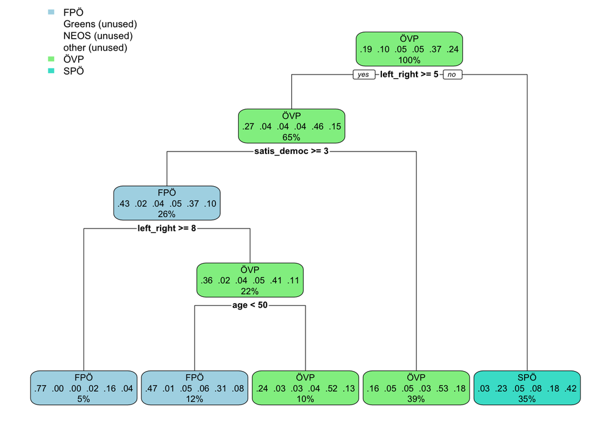

```r
# Model based on "manual" tree
rpart.plot(tree, box.palette=party, nn=FALSE, type=2)
```

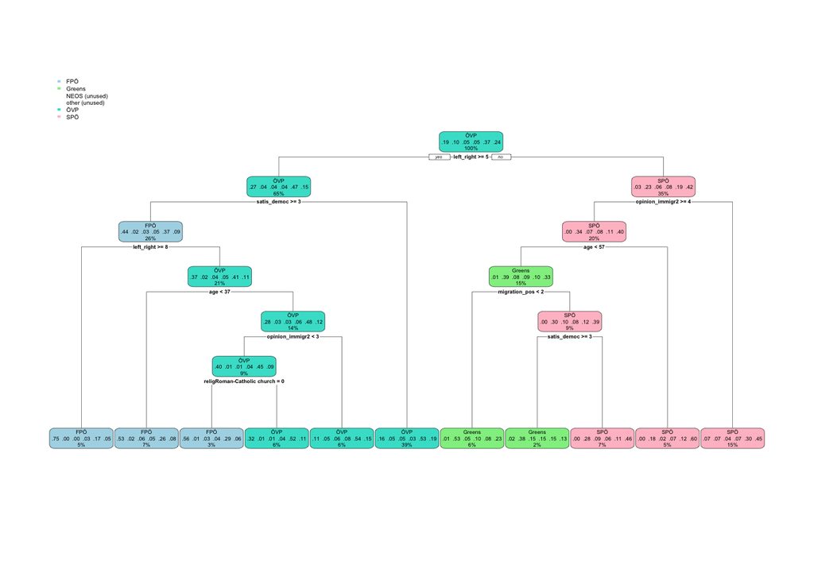

```r
# Model based on tree_caret
tree_caret_final <- tree_caret$finalModel
rpart.plot(tree_caret_final, box.palette=party, nn=FALSE, type=2)
```

Now we look at the tree when using the caret package. As explained before when looking at the rpart-object we start in the root node (our positive class) and from there start going down to the next node defined by the rules at which the tree splits. As visulaized we end up with 11 terminal nodes and 10 splits. Here we also see the probability of the parties receiving a vote based on the splitting rules. For example take the terminal node to the right, SPÖ (15%), we get here by starting at the root node. The first split happens on whether the left_right self-placement is larger or equal to 5 if this is not the case (with a probability of 35% we are in the parent node SPÖ. From here if opinion_immigr2 is smaller 4 we end up in the terminal node SPÖ with a probability of 15%. The classes NEOS and other are still unused in the caret tree.

# **Task 3** Confusion matrix

In order to assess and compare the performance of the two models we create a confusion matrix. We use the test data since in the training data our model is always more accurate:

```r
# Model based on "manual" tree
test$prediction_tree <- predict(tree, newdata = test, type = c("class"))
confusion <- confusionMatrix(test$vote, test$prediction_tree,positive = "ÖVP", mode="sens_spec")
confusion
```

```
## Confusion Matrix and Statistics
##
##           Reference
## Prediction FPÖ Greens NEOS other ÖVP SPÖ
##     FPÖ     34      0    0     0  24   6
##     Greens   1      0    0     0   7  27
##     NEOS     2      0    0     0   4  10
##     other    2      0    0     0   7  11
##     ÖVP     16      0    0     0  94  28
##     SPÖ      4      0    0     0  34  53
##
## Overall Statistics
##
##                Accuracy : 0.4973
##                  95% CI : (0.4447, 0.5498)
##     No Information Rate : 0.467
##     P-Value [Acc > NIR] : 0.135
##
##                   Kappa : 0.2835
##
##  Mcnemar's Test P-Value : NA
##
## Statistics by Class:
##
##                      Class: FPÖ Class: Greens Class: NEOS Class: other
## Sensitivity             0.57627            NA          NA           NA
## Specificity             0.90164       0.90385     0.95604      0.94505
## Pos Pred Value          0.53125            NA          NA           NA
## Neg Pred Value          0.91667            NA          NA           NA
## Prevalence              0.16209       0.00000     0.00000      0.00000
## Detection Rate          0.09341       0.00000     0.00000      0.00000
## Detection Prevalence    0.17582       0.09615     0.04396      0.05495
## Balanced Accuracy       0.73896            NA          NA           NA
##                      Class: ÖVP Class: SPÖ
## Sensitivity              0.5529     0.3926
## Specificity              0.7732     0.8341
## Pos Pred Value           0.6812     0.5824
## Neg Pred Value           0.6637     0.6996
## Prevalence               0.4670     0.3709
## Detection Rate           0.2582     0.1456
## Detection Prevalence     0.3791     0.2500
## Balanced Accuracy        0.6631     0.6133
```

```r
# Model based on tree_caret
test$prediction_tree_caret <- predict.train(tree_caret, newdata = test, type = c("raw"), na.action = na.rpart)
confusion <- confusionMatrix(test$vote, test$prediction_tree_caret,positive = "ÖVP", mode="sens_spec")
confusion
```

```
## Confusion Matrix and Statistics
##
##           Reference
## Prediction FPÖ Greens NEOS other ÖVP SPÖ
##     FPÖ     34      0    0     0  24   6
##     Greens   1     11    0     0   7  16
##     NEOS     1      3    0     0   5   7
##     other    2      6    0     0   7   5
##     ÖVP     12      3    0     0  98  25
##     SPÖ      4      8    0     0  34  45
##
## Overall Statistics
##
##                Accuracy : 0.5165
##                  95% CI : (0.4638, 0.5689)
##     No Information Rate : 0.4808
##     P-Value [Acc > NIR] : 0.09492
##
##                   Kappa : 0.3209
##
##  Mcnemar's Test P-Value : NA
##
## Statistics by Class:
##
##                      Class: FPÖ Class: Greens Class: NEOS Class: other
## Sensitivity             0.62963       0.35484          NA           NA
## Specificity             0.90323       0.92793     0.95604      0.94505
## Pos Pred Value          0.53125       0.31429          NA           NA
## Neg Pred Value          0.93333       0.93921          NA           NA
## Prevalence              0.14835       0.08516     0.00000      0.00000
## Detection Rate          0.09341       0.03022     0.00000      0.00000
## Detection Prevalence    0.17582       0.09615     0.04396      0.05495
## Balanced Accuracy       0.76643       0.64138          NA           NA
##                      Class: ÖVP Class: SPÖ
## Sensitivity              0.5600     0.4327
## Specificity              0.7884     0.8231
## Pos Pred Value           0.7101     0.4945
## Neg Pred Value           0.6593     0.7839
## Prevalence               0.4808     0.2857
## Detection Rate           0.2692     0.1236
## Detection Prevalence     0.3791     0.2500
## Balanced Accuracy        0.6742     0.6279
```

Looking at the important measures of both models in the confusion matrix we see that in the model we estimated doing CV manually, both accuracy and kappa are as expected smaller. This indicates that the model we estimated using the caret package performs better! Considering the sensitivity and specificity we also see that the tree_caret performs better in almost all of the classes than with the simple tree model. Furthermore, balanced accuracy improved for FPÖ, Greens, ÖVP and SPÖ. In general the accuracy and kappa for both models are not really high, with only about 0.5165 and 0.3209 respectively. To get a better overview of the trade-off between the indicators of the confusion matrix we should look at ROC curves. Moreover, with caret our p-value decreased, altough still not being significant.

**Regarding which two categories do you find the highest and lowest sensitivity?**

We have the highest sensitivity or a vote outcome for FPÖ (model: tree_caret) with a probability of 62,96% and the lowest in Greens with a probability of 35,48%.

**How well would you judge the predictive performance of the model?**

Given the accuracy rate and the kappa value the predictive performance of the model, the predictive performance is not very good! (see above). Our tree just assigns a bit more than 50% of the votes to the true party. Also the no information rate is very high and clearly not significant from zero. Therefore, the tree does not estimate differently from a naive classifier.

**What would be the “naive prediction” in such a multiclass prediction problem?**

The naive prediction is that a voter votes for ÖVP (positive class).

# **Task 4**

**Estimate the model across a wide range of parameters of the model and plot the accuracy in the training and in the test data against the parameters. What can you see? what problem does this relate to?**

In order to estimate the model across a wider range of parameters of the model we use differently tuned parameters. Since in our first model we already used a rather small complexity parameter we here lower the frequency of the steps in between. Leading to a larger tuning grid and more cp to try out. Another possibility would be to also increase / change the type of CV. Due to the time constraint we refrain from this here. We then plot the training and test data against the parameters.

```r
control_new <- trainControl(method = "repeatedcv", number = 10, repeats = 10, savePredictions = T, classProbs = T, summaryFunction = multiClassSummary)

tuning_grid_new <- expand.grid(cp = seq(0, 0.01, by= 0.001))
tuning_grid_new
```

```
##       cp
## 1  0.000
## 2  0.001
## 3  0.002
## 4  0.003
## 5  0.004
## 6  0.005
## 7  0.006
## 8  0.007
## 9  0.008
## 10 0.009
## 11 0.010
```

```r
tree_caret_train <- train(data = train, formula , method = "rpart", trControl = control_new, tuneGrid = tuning_grid_new, metric = "Accuracy", na.action = na.pass)
tree_caret_train
```

```
## CART
##
## 2145 samples
##    7 predictor
##    6 classes: 'FPÖ', 'Greens', 'NEOS', 'other', 'ÖVP', 'SPÖ'
##
## No pre-processing
## Resampling: Cross-Validated (10 fold, repeated 10 times)
## Summary of sample sizes: 1931, 1930, 1930, 1929, 1932, 1930, ...
## Resampling results across tuning parameters:
##
##   cp     logLoss   AUC        prAUC      Accuracy   Kappa      Mean_F1
##   0.000  3.521954  0.6975612  0.3051569  0.4808091  0.2886884  0.3944871
##   0.001  2.623132  0.7041558  0.3000270  0.4944215  0.3025471  0.3858160
##   0.002  1.900667  0.7109400  0.2917440  0.5023794  0.3097535        NaN
##   0.003  1.523127  0.7121533  0.2670968  0.5011268  0.3043700        NaN
##   0.004  1.418710  0.7055779  0.2460311  0.5004828  0.3013449        NaN
##   0.005  1.390697  0.6998595  0.2341728  0.4984654  0.2968278        NaN
##   0.006  1.378339  0.6977101  0.2318860  0.4983706  0.2956751        NaN
##   0.007  1.373319  0.6948898  0.2231497  0.4944975  0.2904324        NaN
##   0.008  1.373349  0.6928451  0.2149211  0.4900701  0.2846928        NaN
##   0.009  1.376299  0.6876199  0.1929544  0.4825980  0.2728396        NaN
##   0.010  1.385802  0.6814236  0.1666911  0.4749126  0.2597133        NaN
##   Mean_Sensitivity  Mean_Specificity  Mean_Pos_Pred_Value  Mean_Neg_Pred_Value
##   0.3353619         0.8807212         0.3401615            0.8835982
##   0.3416811         0.8827538         0.3513219            0.8864351
##   0.3456830         0.8836647         0.3545683            0.8881339
##   0.3395098         0.8826678               NaN            0.8876265
##   0.3378703         0.8819916               NaN            0.8871513
##   0.3356203         0.8811006               NaN            0.8867086
##   0.3348556         0.8808410               NaN            0.8866992
##   0.3310649         0.8800726               NaN            0.8857824
##   0.3265731         0.8792649               NaN            0.8849270
##   0.3150163         0.8775382               NaN            0.8834949
##   0.3008701         0.8756494               NaN            0.8820143
##   Mean_Precision  Mean_Recall  Mean_Detection_Rate  Mean_Balanced_Accuracy
##   0.3401615       0.3353619    0.08013485           0.6080415
##   0.3513219       0.3416811    0.08240359           0.6122174
##   0.3545683       0.3456830    0.08372990           0.6146739
##         NaN       0.3395098    0.08352113           0.6110888
##         NaN       0.3378703    0.08341379           0.6099309
##         NaN       0.3356203    0.08307756           0.6083605
##         NaN       0.3348556    0.08306176           0.6078483
##         NaN       0.3310649    0.08241624           0.6055687
##         NaN       0.3265731    0.08167835           0.6029190
##         NaN       0.3150163    0.08043299           0.5962773
##         NaN       0.3008701    0.07915210           0.5882598
##
## Accuracy was used to select the optimal model using the largest value.
## The final value used for the model was cp = 0.002.
```

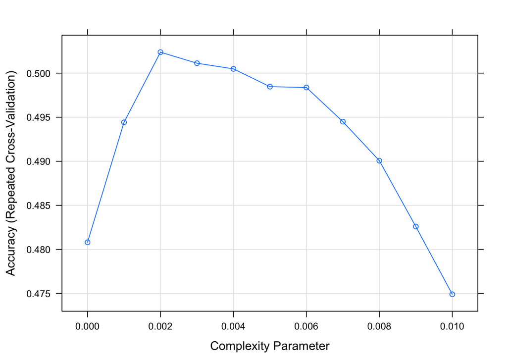

```r
plot(tree_caret_train)
```

Plotting the accuracy in the train data set against the parameter, we see that when increasing the cp parameter (complexitiy, minimum improvement in the model required at each nod) at first accuracy increases and peaks at 0.002 our optimum value (accuracy level > 0.5. Further increasing cp leads to less accuracy. Increasing cp is equivalent to being more restrictive when adding new splits.

```r
tree_caret_test <- train(data = test, formula , method = "rpart", trControl = control_new, tuneGrid = tuning_grid_new, metric = "Accuracy", na.action = na.pass)
tree_caret_test
```

```
## CART
##
## 364 samples
##   7 predictor
##   6 classes: 'FPÖ', 'Greens', 'NEOS', 'other', 'ÖVP', 'SPÖ'
##
## No pre-processing
## Resampling: Cross-Validated (10 fold, repeated 10 times)
## Summary of sample sizes: 328, 327, 328, 328, 328, 325, ...
## Resampling results across tuning parameters:
##
##   cp     logLoss   AUC        prAUC      Accuracy   Kappa      Mean_F1
##   0.000  4.688359  0.6353106  0.2031033  0.4218301  0.1962500  NaN
##   0.001  4.688359  0.6353106  0.2031033  0.4218301  0.1962500  NaN
##   0.002  4.650229  0.6337113  0.2012692  0.4218079  0.1956556  NaN
##   0.003  4.461217  0.6321644  0.1969063  0.4229178  0.1942246  NaN
##   0.004  4.376405  0.6303477  0.1968212  0.4262144  0.1971226  NaN
##   0.005  3.872696  0.6292985  0.1928639  0.4258737  0.1906285  NaN
##   0.006  3.872696  0.6292985  0.1928639  0.4258737  0.1906285  NaN
##   0.007  3.725188  0.6287952  0.1920148  0.4288929  0.1919673  NaN
##   0.008  3.547095  0.6284060  0.1890346  0.4278874  0.1884518  NaN
##   0.009  3.418480  0.6297533  0.1874404  0.4281430  0.1867250  NaN
##   0.010  2.793029  0.6397860  0.1786730  0.4287353  0.1835709  NaN
##   Mean_Sensitivity  Mean_Specificity  Mean_Pos_Pred_Value  Mean_Neg_Pred_Value
##   0.2860386         0.8653869         NaN                  0.8689439
##   0.2860386         0.8653869         NaN                  0.8689439
##   0.2856417         0.8652771         NaN                  0.8689730
##   0.2847431         0.8649753         NaN                  0.8690280
##   0.2856713         0.8654235         NaN                  0.8697948
##   0.2770640         0.8642861         NaN                  0.8695067
##   0.2770640         0.8642861         NaN                  0.8695067
##   0.2767874         0.8644272         NaN                  0.8704681
##   0.2725134         0.8639267         NaN                  0.8701215
##   0.2709882         0.8636102         NaN                  0.8700292
##   0.2680953         0.8631219         NaN                  0.8696680
##   Mean_Precision  Mean_Recall  Mean_Detection_Rate  Mean_Balanced_Accuracy
##   NaN             0.2860386    0.07030501           0.5757127
##   NaN             0.2860386    0.07030501           0.5757127
##   NaN             0.2856417    0.07030132           0.5754594
##   NaN             0.2847431    0.07048630           0.5748592
##   NaN             0.2856713    0.07103574           0.5755474
##   NaN             0.2770640    0.07097894           0.5706751
##   NaN             0.2770640    0.07097894           0.5706751
##   NaN             0.2767874    0.07148215           0.5706073
##   NaN             0.2725134    0.07131457           0.5682201
##   NaN             0.2709882    0.07135717           0.5672992
##   NaN             0.2680953    0.07145589           0.5656086
##
## Accuracy was used to select the optimal model using the largest value.
## The final value used for the model was cp = 0.007.
```

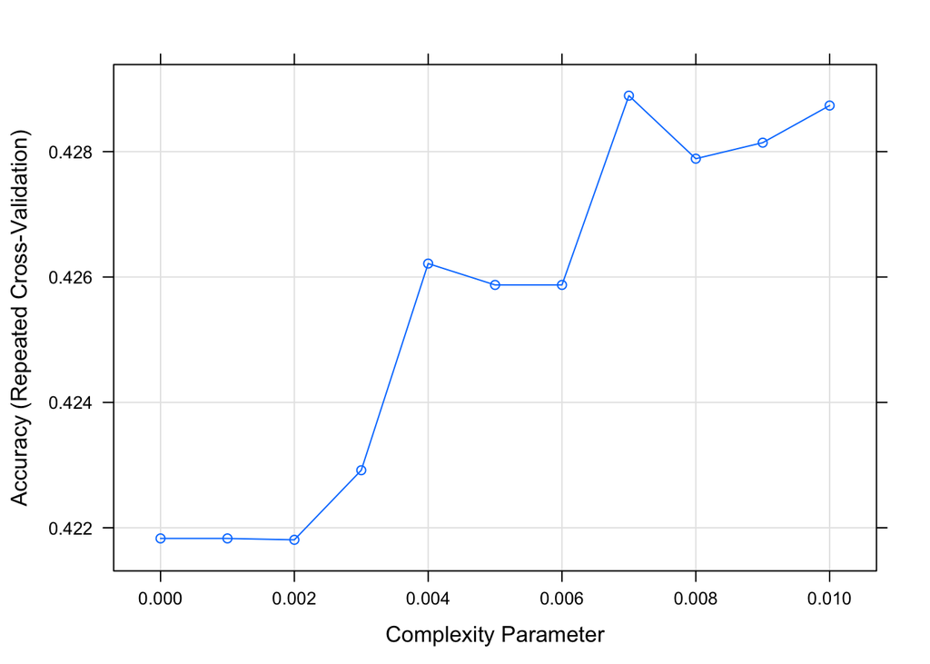

```r
plot(tree_caret_test)
```

Plotting the test data set against the parameter, we see a upwards trend. Increasing the complexity parameter leads to higher accuracy. Accuracy is highest at cp = 0.007.

# **Task 5** Simplified model

**Simplify the model by only trying to predict if somebody voted for the ÖVP or not, re-estimate the model (again by using CV) as well as estimating a logit model in the training data utilizing whatever variables you find appropriate**

The new dummy variable vp which takes the value 1 for ÖVP and 0 otherwise we use here was already created in the beginning. We already specified it in the beginning so that we do not need to seperate the test and training data again. We have a binary classification instead of the multi-class version here. We specify a new formula with our dummy as dependent variable and then use rpart to estimate the tree. Then we compute the confusion model. Second, we estimate a logit model and also compute the confusion matrix to compare the two models and their performance.

# Simplified Tree Model

```r
formula_vp <-  vp_vote ~ age + male + satis_democ + migration_pos + left_right + opinion_immigr2 + relig

tree_vp <- rpart(formula_vp, data = train, cp = 0.005)
tree_vp
```

```
## n= 2145
##
## node), split, n, loss, yval, (yprob)
##       * denotes terminal node
##
##   1) root 2145 787 Yes (0.6331002 0.3668998)
##     2) left_right< 4.5 742 137 Yes (0.8153639 0.1846361) *
##     3) left_right>=4.5 1403 650 Yes (0.5367071 0.4632929)
##       6) relig=Christian-orthodox church,Islamic religious community,none,other,Protestant church,refused 414 125 Yes (0.6980676 0.3019324) *
##       7) relig=Roman-Catholic church 989 464 No (0.4691608 0.5308392)
##        14) age< 39.5 291 113 Yes (0.6116838 0.3883162)
##          28) satis_democ>=2.5 127  36 Yes (0.7165354 0.2834646) *
##          29) satis_democ< 2.5 164  77 Yes (0.5304878 0.4695122)
##            58) age< 18.5 25   7 Yes (0.7200000 0.2800000) *
##            59) age>=18.5 139  69 No (0.4964029 0.5035971)
##             118) migration_pos>=4.5 18   5 Yes (0.7222222 0.2777778) *
##             119) migration_pos< 4.5 121  56 No (0.4628099 0.5371901)
##               238) age>=28.5 54  23 Yes (0.5740741 0.4259259) *
##               239) age< 28.5 67  25 No (0.3731343 0.6268657) *
##        15) age>=39.5 698 286 No (0.4097421 0.5902579)
##          30) opinion_immigr2< 1.5 231 113 Yes (0.5108225 0.4891775)
##            60) satis_democ>=3.5 42  11 Yes (0.7380952 0.2619048) *
##            61) satis_democ< 3.5 189  87 No (0.4603175 0.5396825)
##             122) age< 61.5 83  37 Yes (0.5542169 0.4457831)
##               244) age>=44.5 68  27 Yes (0.6029412 0.3970588) *
##               245) age< 44.5 15   5 No (0.3333333 0.6666667) *
##             123) age>=61.5 106  41 No (0.3867925 0.6132075) *
##          31) opinion_immigr2>=1.5 467 168 No (0.3597430 0.6402570) *
```

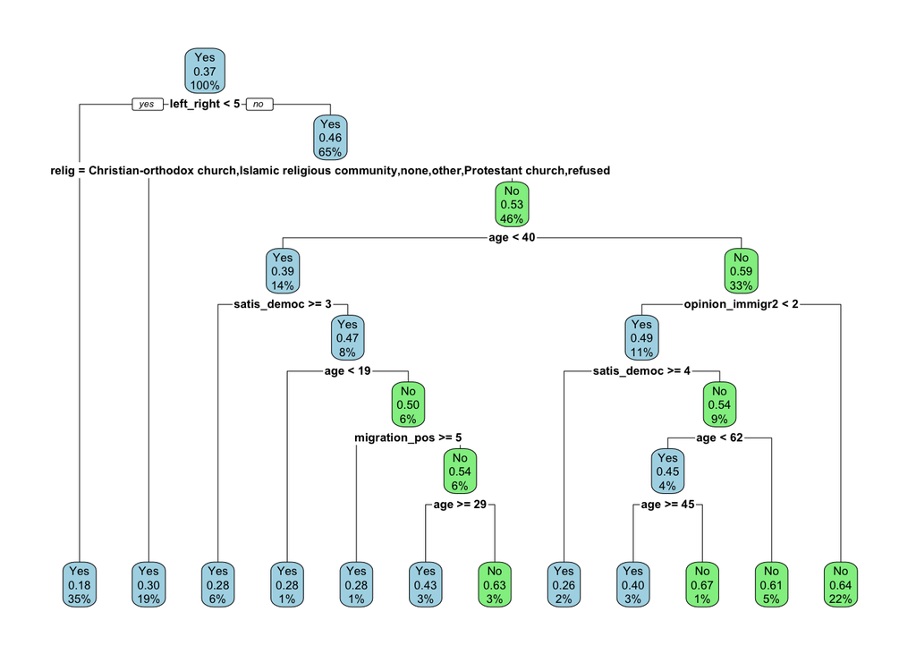

```r
rpart.plot(tree_vp, box.palette=party, nn=FALSE, type=2)
```

# Logit model

```r
logit_vp <- glm(formula_vp,
             data = train, family = "binomial")

summary(logit_vp)
```

```
##
## Call:
## glm(formula = formula_vp, family = "binomial", data = train)
##
## Deviance Residuals:
##     Min       1Q   Median       3Q      Max
## -1.8890  -0.9702  -0.5864   1.1390   2.6525
##
## Coefficients:
##                                    Estimate Std. Error z value Pr(>|z|)
## (Intercept)                       -3.021257   0.710623  -4.252 2.12e-05 ***
## age                                0.015411   0.002631   5.857 4.72e-09 ***
## male                              -0.048952   0.099465  -0.492   0.6226
## satis_democ                       -0.156133   0.065204  -2.395   0.0166 *
## migration_pos                      0.012409   0.006875   1.805   0.0711 .
## left_right                         0.203850   0.027582   7.391 1.46e-13 ***
## opinion_immigr2                   -0.030838   0.039168  -0.787   0.4311
## religdon't know                   -9.719940 324.744408  -0.030   0.9761
## religIslamic religious community  -0.590449   0.987007  -0.598   0.5497
## relignone                          0.234142   0.662129   0.354   0.7236
## religother                         0.916816   0.772557   1.187   0.2353
## religProtestant church             0.839996   0.685967   1.225   0.2207
## religrefused                       0.063284   1.020052   0.062   0.9505
## religRoman-Catholic church         1.495375   0.653023   2.290   0.0220 *
## ---
## Signif. codes:  0 '***' 0.001 '**' 0.01 '*' 0.05 '.' 0.1 ' ' 1
##
## (Dispersion parameter for binomial family taken to be 1)
##
##     Null deviance: 2656.8  on 2008  degrees of freedom
## Residual deviance: 2385.5  on 1995  degrees of freedom
##   (136 observations deleted due to missingness)
## AIC: 2413.5
##
## Number of Fisher Scoring iterations: 11
```

# **Task 6** Confusion matrix and ROC-curves

**Compute the confusion matrix and ROC-curves for both models. Which one performs better and why? Where would you set the cut-off-point?**

# Confusion Matrix simplified tree model

```r
test$prediction_tree_vp <- predict(tree_vp, newdata = test, type = c("class"))
test <- test %>%
  drop_na(prediction_tree_vp)

confusion <- confusionMatrix(test$vp_vote,test$prediction_tree_vp)
confusion
```

```
## Confusion Matrix and Statistics
##
##           Reference
## Prediction Yes  No
##        Yes 189  37
##        No   72  66
##
##                Accuracy : 0.7005
##                  95% CI : (0.6506, 0.7472)
##     No Information Rate : 0.717
##     P-Value [Acc > NIR] : 0.776348
##
##                   Kappa : 0.3309
##
##  Mcnemar's Test P-Value : 0.001128
##
##             Sensitivity : 0.7241
##             Specificity : 0.6408
##          Pos Pred Value : 0.8363
##          Neg Pred Value : 0.4783
##              Prevalence : 0.7170
##          Detection Rate : 0.5192
##    Detection Prevalence : 0.6209
##       Balanced Accuracy : 0.6825
##
##        'Positive' Class : Yes
##
```

```r
test$prediction_logit <- predict(logit_vp, newdata = test, type = "response")

test <- test %>%
  mutate(prediction_logit=as.factor(ifelse(prediction_logit>0.5,"Yes","No"))) %>%
  drop_na(prediction_logit)

confusion <- confusionMatrix(test$vp_vote, test$prediction_logit)
confusion
```

```
## Confusion Matrix and Statistics
##
##           Reference
## Prediction  No Yes
##        No   75  51
##        Yes 173  36
##
##                Accuracy : 0.3313
##                  95% CI : (0.2811, 0.3846)
##     No Information Rate : 0.7403
##     P-Value [Acc > NIR] : 1
##
##                   Kappa : -0.195
##
##  Mcnemar's Test P-Value : 6.234e-16
##
##             Sensitivity : 0.3024
##             Specificity : 0.4138
##          Pos Pred Value : 0.5952
##          Neg Pred Value : 0.1722
##              Prevalence : 0.7403
##          Detection Rate : 0.2239
##    Detection Prevalence : 0.3761
##       Balanced Accuracy : 0.3581
##
##        'Positive' Class : No
##
```

ROC

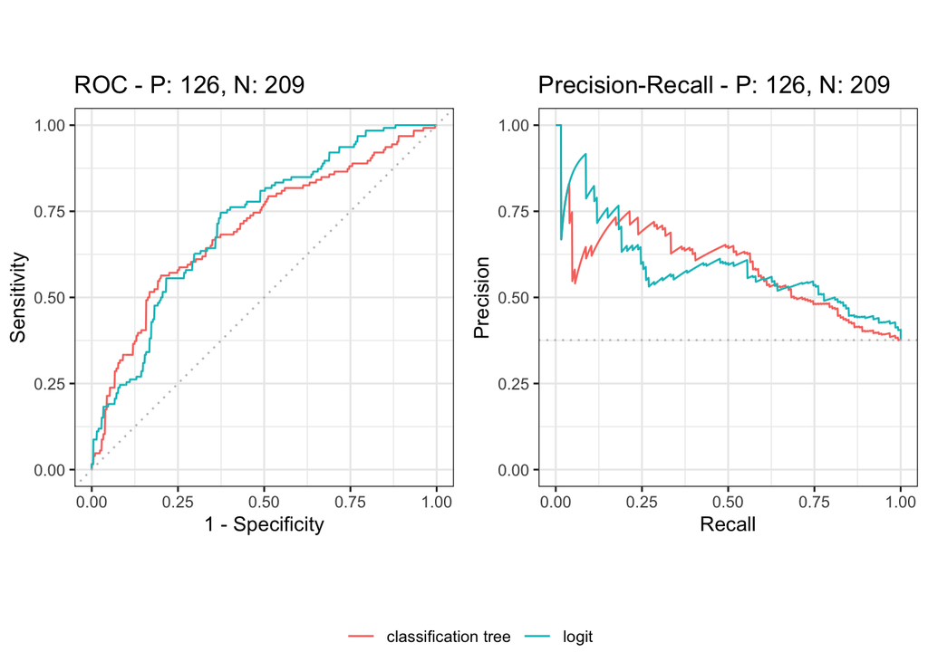

```r
test$prediction_tree_scores <- predict(tree_vp, test ,type = c("prob"))[,2]
test$prediction_logit_scores <- predict(logit_vp, test ,type = c("response"))

precrec_obj <- evalmod(scores = cbind(test$prediction_tree_scores, test$prediction_logit_scores), labels = cbind(test$vp_vote,test$vp_vote),modnames = c("classification tree","logit"), raw_curves = FALSE, ties_method="first")

autoplot(precrec_obj)
```